# ReSolve Asset Management — Lazy Money SMA

[figure not shown]

Put Your Lazy Money  
to Work

Portable Alpha for the Mid-Market

[figure not shown]

What is Return Stacking?

Why ReSolve?

- 20+ years of quantitative research heritage
- Systematic carry, trend, and volatility strategies across 50+ global futures markets
- True portable alpha: uncorrelated to stocks and bonds
- Institutional infrastructure, mid-market accessibility
- Separately managed accounts with full transparency

"ReSolve has delivered institutional-grade alpha that has genuinely enhanced our portfolio construction."

— Jonathan Glidden, Former CIO, Delta Air Lines

[figure not shown]

[figure not shown]

Building Blocks for a  
Robust Stacked Portfolio

Case Study on a Live ReSolve Carry Mandate

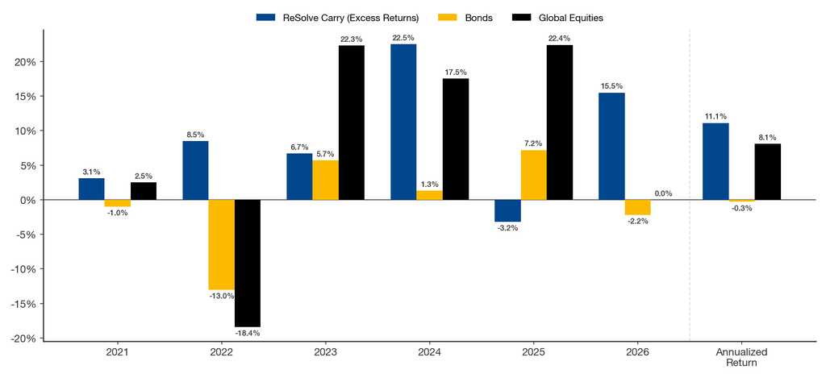

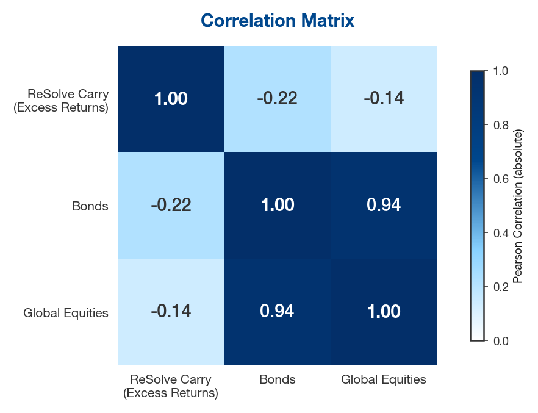

| Statistics | Balanced Portfolio | Carry (Excess Returns) | 100% Balanced + 100% Carry |
| --- | --- | --- | --- |
| Annualized Return | 4.92% | 11.34% | 17.90% |
| Annualized Volatility | 11.14% | 22.08% | 20.43% |
| Max Drawdown | -21.23% | -23.98% | -14.71% |
| Sharpe Ratio | 0.44 | 0.51 | 0.88 |

$2B+ in AUM across strategies

Sub-advised for major ETF platforms

CFTC-registered CTA

SEC-registered RIA

Ready to put your lazy money to work?

info@investresolve.com | www.investresolve.com

[figure not shown]

Source: Tiingo. Analysis by ReSolve Asset Management SEZC (Cayman). ReSolve Carry is ReSolve Futures Yield (Carry) 20% Volatility Program (Excess Returns). Bonds is the iShares Core U.S. Aggregate Bond ETF (AGG). Global Equities is the iShares MSCI ACWI ETF (ACWI). Period is from September 1, 2021 through March 31, 2026. Indicated returns of one year or more are annualized. These results are a carveout of returns for the Program. All performance data is provided by the third party fund admin less a 0.85% annual fee.

PAST PERFORMANCE IS NOT A GUARANTEE OF FUTURE RESULTS. THE RISK OF LOSS IN TRADING COMMODITY INTERESTS IS SUBSTANTIAL. These materials do not constitute an offer or solicitation of an offer to make an investment in any of the funds or separately managed accounts ReSolve Global manages. ReSolve Global operates within a fund of funds and as excess returns (calculated prior to any yield on posted collateral). Confidential — Qualified Eligible Purchasers Only.

[figure not shown]